# POC replicate table 2 of the previous paper by analysis the type of countries, goods and cities

# Objective(s)

Replicate the second table of the previous paper

[figure not shown]

- LDC and DC comes from the world bank classification, and are already in the table
- The list of homogeneous goods is in the S3
- Small/large city is be computed by using:
  - the number of product exported in 2003. If the count of product is above average, then it can be consider as a large firm
  - The average quantity

# Metadata

- Epic: Epic 2
- US: US 2
- Date Begin: 10/4/2020
- Duration Task: 1
- Description: Replicate table 2 with and without the export share covariates
- Step type:
- Status: Active
- Source URL: US 02 Table 2 country, good city
- Task type: Jupyter Notebook
- Users: Thomas Pernet
- Watchers: Thomas Pernet
- User Account: https://468786073381.signin.aws.amazon.com/console
- Estimated Log points: 10
- Task tag: #econometrics,#ols
- Toggl Tag: #model-training
- Meetings:
- Email Information:
  - thread: Number of threads: 0(Default 0, to avoid display email)

# Input Cloud Storage [AWS/GCP]

## Table/file

- Origin:
- Athena
- Name:
- quality_vat_export_covariate_2003_2010
- Github:
  - https://github.com/thomaspernet/VAT_rebate_quality_china/blob/master/01_data_preprocessing/02_prepare_tables_model/02_transform_table_baseline_covariates.md

# Connexion server

```python
from awsPy.aws_authorization import aws_connector
from awsPy.aws_s3 import service_s3
from awsPy.aws_glue import service_glue
from pathlib import Path
import pandas as pd
import numpy as np
#import seaborn as sns
import os, shutil

path = os.getcwd()
parent_path = str(Path(path).parent.parent.parent)


name_credential = 'thomas_vat_credentials.csv'
region = 'eu-west-3'
bucket = 'chinese-data'
path_cred = "{0}/creds/{1}".format(parent_path, name_credential)
```

```python
con = aws_connector.aws_instantiate(credential = path_cred,
                                       region = region)
client= con.client_boto()
s3 = service_s3.connect_S3(client = client,
                      bucket = bucket, verbose = False)
glue = service_glue.connect_glue(client = client)
```

```python
pandas_setting = True
if pandas_setting:
    #cm = sns.light_palette("green", as_cmap=True)
    pd.set_option('display.max_columns', None)
    pd.set_option('display.max_colwidth', None)
```

# Load tables

Since we load the data as a Pandas DataFrame, we want to pass the `dtypes`. We load the schema from Glue to guess the types

- Filename: XX
- Main table S3: https://s3.console.aws.amazon.com/s3/buckets/vat-rebate-quality/DATA/TRANSFORMED/?region=eu-west-3&tab=overview
- List homogeneous goods: https://s3.console.aws.amazon.com/s3/buckets/chinese-data/TRADE_DATA/RAW/GOODS_CLASSIFICATION/HOMOGENEOUS/?region=eu-west-3&tab=overview

```python
s3.download_file(
        key = 'TRADE_DATA/RAW/GOODS_CLASSIFICATION/HOMOGENEOUS/homogeneous.csv',
    path_local = os.path.join(str(Path(path).parent.parent.parent),
                              "00_data_catalogue/temporary_local_data")
)
```

# Models to estimate

The model to estimate is:

## Fixed Effect

| Benchmark | Origin | Name | Description | Math_notebook |
| --- | --- | --- | --- | --- |
| Yes | Current | city-product |  | $\alpha_{ck}$ |
| Yes | Current | city-product-regime |  | $\alpha_{ck}^R$ |
| Yes | Current | city-sector-year | Sector is defined as GBT 4 digit | $\alpha_{cst}$ |
| Yes | Current | city-sectorーregime-year | Sector is defined as GBT 4 digit | $\alpha_{cst}^R$ |
| Yes | Current | product-destination |  | $\alpha_{pj}$ |
| Yes | Previous baseline | Product-year | account for all factors that affect product-level export irrespective of the trade regime in a given year | $\alpha_{pt}$ |
| No | Previous baseline | firm-product-eligibility | captures all the factors that affect firms regardless of the time and type of regime. This firm‒product pair eliminates the demand shocks that firms face and that are not correlated with the types of … | $\alpha^{E}_{it}$ |
| No | Previous baseline | HS4-year-eligibility |  | $\alpha^{E}_{st}$ |
| No | Previous baseline | city-year | captures the differences in demand, capital intensity, or labor supply that prevail between cities each year | $\alpha_{ct}$ |
| No | Candidate | destination-year | Captures additional level of control, encompassing all the shocks and developments in the economies to which China exports. | $\alpha_{dt}$ |

- city-product: `fe_ck`
- City-sector-year: `fe_cst`
- City-product-regime: `fe_ckr`
- City-sector-regime-year: `fe_csrt`
- Product-year: `fe_kt`
- Product-destination: `fe_pj`
- Destination-year: `fe_jt`

```python
import function.latex_beautify as lb

%load_ext autoreload
%autoreload 2
```

```python
options(warn=-1)
library(tidyverse)
library(lfe)
#library(lazyeval)
library('progress')
path = "function/table_golatex.R"
source(path)
```

```
 Hlavac, Marek (2018). stargazer: Well-Formatted Regression and Summary Statistics Tables.

 R package version 5.2.2. https://CRAN.R-project.org/package=stargazer
```

Code to get the list of homogeneous list. `hs6.csv` is the list of HS6 in the database

```
library(concordance)
hs6 <- read_csv('hs6.csv', col_types = "c") %>%
mutate(goods=sapply(hs6, function(x) { get_proddiff(sourcevar = x, "hs", prop = "w") })) %>%
mutate(homogeneous = ifelse(goods > 0.5, "HOMOGENEOUS", "HETEREGENEOUS"))
write.csv(hs6, 'homogeneous.csv')
```

```python
path = '../../../00_Data_catalogue/temporary_local_data/homogeneous.csv'
homogeneous <- read_csv(path, col_types = "dcc")
head(homogeneous)
```

A tibble: 6 × 3

| hs6 <dbl> | goods <chr> | homogeneous <chr> |
| --- | --- | --- |
| 621149 | 0 | HETEREGENEOUS |
| 630260 | 0 | HETEREGENEOUS |
| 630391 | 0 | HETEREGENEOUS |
| 720219 | 0 | HETEREGENEOUS |
| 720510 | 0 | HETEREGENEOUS |
| 940190 | 0 | HETEREGENEOUS |

```python
path = '../../../00_Data_catalogue/temporary_local_data/quality_vat_export_covariate_2003_2010.csv'
df_final <- read_csv(path) %>%
mutate_if(is.character, as.factor) %>%
    mutate_at(vars(starts_with("fe")), as.factor) %>%
mutate(regime = relevel(regime, ref='NOT_ELIGIBLE')) %>%
left_join(homogeneous, by= "hs6")
```

## Table 1: Countries, goods and cities characteristics, no covariates

$$ \begin{aligned} \operatorname{Quality}_{c,k,j, t}^{R} &=\alpha \ln \operatorname{VAT} \operatorname{Export} \operatorname{tax}_{k, t-1} \times \text { Eligibility }^{R} \\ &+F E_{c,k}^{R}+F E_{c,s,t}^{R}+ F E_{k, t}+\epsilon_{ck,j, t}^{R} \end{aligned} $$

- Column 1: Estimate baseline regression subset LDC countries: `income_group_ldc_dc` -> `LDC`
  - FE:
    - city-product-regime: `fe_ckr`
    - city-sector-regime-year: `fe_csrt`
    - product-year: `fe_kt`
- Column 2: Estimate baseline regression subset DC countries: `income_group_ldc_dc` -> `DC`
  - FE:
    - city-product-regime: `fe_ckr`
    - city-sector-regime-year: `fe_csrt`
    - product-year: `fe_kt`
- Column 3: Estimate baseline regression subset Homogeneous goods: `classification` -> `HOMOGENEOUS`
  - FE:
    - city-product-regime: `fe_ckr`
    - city-sector-regime-year: `fe_csrt`
    - product-year: `fe_kt`
- Column 4: Estimate baseline regression subset heterogeneous goods: `classification` -> != `HOMOGENEOUS`
  - FE:
    - city-product-regime: `fe_ckr`
    - city-sector-regime-year: `fe_csrt`
    - product-year: `fe_kt`
- Column 5: Estimate baseline regression subset small cities: `size_product` -> == `SMALL_COUNT`
  - FE:
    - city-product-regime: `fe_ckr`
    - city-sector-regime-year: `fe_csrt`
    - product-year: `fe_kt`
- Column 6: Estimate baseline regression subset large cities: `size_product` -> == `LARGE_COUNT`
  - FE:
    - city-product-regime: `fe_ckr`
    - city-sector-regime-year: `fe_csrt`
    - product-year: `fe_kt`
- Column 7: Estimate baseline regression subset small cities: `size_quantity` -> == `SMALL_QUANTITY`
  - FE:
    - city-product-regime: `fe_ckr`
    - city-sector-regime-year: `fe_csrt`
    - product-year: `fe_kt`
- Column 8: Estimate baseline regression subset large cities: `size_quantity` -> == `LARGE_QUANTITY`
  - FE:
    - city-product-regime: `fe_ckr`
    - city-sector-regime-year: `fe_csrt`
    - product-year: `fe_kt`

Sector is defined as the GBT 4 digits

```python
#### COUNTRIES
t_0 <- felm(kandhelwal_quality ~ln_lag_tax_rebate* regime + ln_lag_import_tax * regime+ ln_lag_import_tax
            | fe_ckr + fe_csrt+fe_kt|0 | hs6, df_final %>% filter(income_group_ldc_dc == 'LDC'),
            exactDOF = TRUE)

t_1 <- felm(kandhelwal_quality ~ln_lag_tax_rebate* regime + ln_lag_import_tax * regime+ ln_lag_import_tax
            | fe_ckr + fe_csrt+fe_kt|0 | hs6, df_final %>% filter(income_group_ldc_dc != 'LDC'),
            exactDOF = TRUE)

#### GOODS
t_2 <- felm(kandhelwal_quality ~ln_lag_tax_rebate* regime + ln_lag_import_tax * regime+ ln_lag_import_tax
            | fe_ckr + fe_csrt+fe_kt|0 | hs6, df_final %>% filter(is.na(homogeneous) | homogeneous == 'HOMOGENEOUS'),
            exactDOF = TRUE)

t_3 <- felm(kandhelwal_quality ~ln_lag_tax_rebate* regime + ln_lag_import_tax * regime+ ln_lag_import_tax
            | fe_ckr + fe_csrt+fe_kt|0 | hs6, df_final %>% filter(homogeneous == 'HETEREGENEOUS'),
            exactDOF = TRUE)

#### CITIES
##### HS6
t_4 <- felm(kandhelwal_quality ~ln_lag_tax_rebate* regime + ln_lag_import_tax * regime+ ln_lag_import_tax
            | fe_ckr + fe_csrt+fe_kt|0 | hs6, df_final %>% filter(size_product == 'SMALL_COUNT'),
            exactDOF = TRUE)

t_5 <- felm(kandhelwal_quality ~ln_lag_tax_rebate* regime + ln_lag_import_tax * regime+ ln_lag_import_tax
            | fe_ckr + fe_csrt+fe_kt|0 | hs6, df_final %>% filter(size_product == 'LARGE_COUNT'),
            exactDOF = TRUE)
##### Quantity
t_6 <- felm(kandhelwal_quality ~ln_lag_tax_rebate* regime + ln_lag_import_tax * regime+ ln_lag_import_tax
            | fe_ckr + fe_csrt+fe_kt|0 | hs6, df_final %>% filter(size_quantity == 'SMALL_QUANTITY'),
            exactDOF = TRUE)

t_7 <- felm(kandhelwal_quality ~ln_lag_tax_rebate* regime + ln_lag_import_tax * regime+ ln_lag_import_tax
            | fe_ckr + fe_csrt+fe_kt|0 | hs6, df_final %>% filter(size_quantity == 'LARGE_QUANTITY'),
            exactDOF = TRUE)
```

```python
import os
try:
    os.remove("Tables/table_0.txt")
except:
    pass
try:
    os.remove("Tables/table_0.tex")
except:
    pass
try:
    os.remove("Tables/table_0.pdf")
except:
    pass
```

```python
dep <- "Dependent variable: Product quality"
fe1 <- list(
    c("City-product-regime fixed effects","Yes", "Yes", "Yes", "Yes","Yes", "Yes","Yes", "Yes"),

    c("City-sector-regime-year fixed effects","Yes", "Yes", "Yes", "Yes","Yes", "Yes","Yes", "Yes"),

    c("product-year fixed effects", "Yes", "Yes", "Yes", "Yes","Yes", "Yes","Yes", "Yes")
             )

table_1 <- go_latex(list(
    t_0,t_1, t_2, t_3, t_4,t_5, t_6, t_7
),
    title="VAT export tax and firm’s quality upgrading, characteristics of the destination countries, products, and cities",
    dep_var = dep,
    addFE=fe1,
    save=TRUE,
    note = FALSE,
    name="Tables/table_0.txt"
)
```

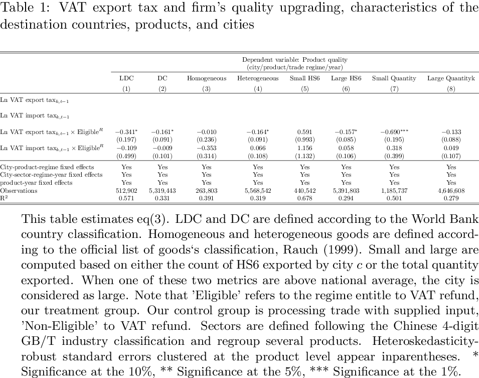

```python
tbe1  = """
This table estimates eq(3).
LDC and DC are defined according to the World Bank country classification.
Homogeneous and heterogeneous goods are defined according to the official list of goods`s classification, Rauch (1999).
Small and large are computed based on either the count of HS6 exported by city $c$ or the total quantity exported.
When one of these two metrics are above national average, the city is considered as large.
Note that 'Eligible' refers to the regime entitle to VAT refund, our treatment group.
Our control group is processing trade with supplied input, 'Non-Eligible' to VAT refund.
Sectors are defined following the Chinese 4-digit GB/T industry
classification and regroup several products.
Heteroskedasticity-robust standard errors
clustered at the product level appear inparentheses.
\sym{*} Significance at the 10\%, \sym{**} Significance at the 5\%, \sym{***} Significance at the 1\%."""

multicolumn ={
    'LDC': 1,
    'DC': 1,
    'Homogeneous': 1,
    'Heterogeneous': 1,
    'Small HS6': 1,
    'Large HS6': 1,
    'Small Quantity': 1,
    'Large Quantityk': 1,
}
multi_lines_dep = '(city/product/trade regime/year)'
#new_r = ['& Eligible', 'Non-Eligible', 'All', 'All benchmark']
lb.beautify(table_number = 0,
            #multi_lines_dep = None,
            multi_lines_dep = multi_lines_dep,
            new_row= False,
            multicolumn = multicolumn,
            table_nte = tbe1,
            jupyter_preview = True,
            resolution = 200)
```

## Table 2: Countries, goods and cities characteristics, with covariates city, regime destination, product

$$ \begin{aligned} \operatorname{Quality}_{c,k,j, t}^{R} &=\alpha \ln \operatorname{VAT} \operatorname{Export} \operatorname{tax}_{k, t-1} \times \text { Eligibility }^{R} \\ &+F E_{c,k}^{R}+F E_{c,s,t}^{R}+ F E_{k, t}+\epsilon_{ck,j, t}^{R} \end{aligned} $$

- Column 1: Estimate baseline regression subset LDC countries: `income_group_ldc_dc` -> `LDC`
  - FE:
    - city-product-regime: `fe_ckr`
    - city-sector-regime-year: `fe_csrt`
    - product-year: `fe_kt`
- Column 2: Estimate baseline regression subset DC countries: `income_group_ldc_dc` -> `DC`
  - FE:
    - city-product-regime: `fe_ckr`
    - city-sector-regime-year: `fe_csrt`
    - product-year: `fe_kt`
- Column 3: Estimate baseline regression subset Homogeneous goods: `classification` -> `HOMOGENEOUS`
  - FE:
    - city-product-regime: `fe_ckr`
    - city-sector-regime-year: `fe_csrt`
    - product-year: `fe_kt`
- Column 4: Estimate baseline regression subset heterogeneous goods: `classification` -> != `HOMOGENEOUS`
  - FE:
    - city-product-regime: `fe_ckr`
    - city-sector-regime-year: `fe_csrt`
    - product-year: `fe_kt`
- Column 5: Estimate baseline regression subset small cities: `size_product` -> == `SMALL_COUNT`
  - FE:
    - city-product-regime: `fe_ckr`
    - city-sector-regime-year: `fe_csrt`
    - product-year: `fe_kt`
- Column 6: Estimate baseline regression subset large cities: `size_product` -> == `LARGE_COUNT`
  - FE:
    - city-product-regime: `fe_ckr`
    - city-sector-regime-year: `fe_csrt`
    - product-year: `fe_kt`
- Column 7: Estimate baseline regression subset small cities: `size_quantity` -> == `SMALL_QUANTITY`
  - FE:
    - city-product-regime: `fe_ckr`
    - city-sector-regime-year: `fe_csrt`
    - product-year: `fe_kt`
- Column 8: Estimate baseline regression subset large cities: `size_quantity` -> == `LARGE_QUANTITY`
  - FE:
    - city-product-regime: `fe_ckr`
    - city-sector-regime-year: `fe_csrt`
    - product-year: `fe_kt`

Sector is defined as the GBT 4 digits

```python
#### COUNTRIES
t_0 <- felm(kandhelwal_quality ~ln_lag_tax_rebate* regime + ln_lag_import_tax * regime+ ln_lag_import_tax +
            lag_foreign_export_share_ckjr + lag_soe_export_share_ckjr
            | fe_ckr + fe_csrt+fe_kt|0 | hs6, df_final %>% filter(income_group_ldc_dc == 'LDC'),
            exactDOF = TRUE)

t_1 <- felm(kandhelwal_quality ~ln_lag_tax_rebate* regime + ln_lag_import_tax * regime+ ln_lag_import_tax +
            lag_foreign_export_share_ckjr + lag_soe_export_share_ckjr
            | fe_ckr + fe_csrt+fe_kt|0 | hs6, df_final %>% filter(income_group_ldc_dc != 'LDC'),
            exactDOF = TRUE)

#### GOODS
t_2 <- felm(kandhelwal_quality ~ln_lag_tax_rebate* regime + ln_lag_import_tax * regime+ ln_lag_import_tax +
            lag_foreign_export_share_ckjr + lag_soe_export_share_ckjr
            | fe_ckr + fe_csrt+fe_kt|0 | hs6, df_final %>% filter(is.na(homogeneous) | homogeneous == 'HOMOGENEOUS'),
            exactDOF = TRUE)

t_3 <- felm(kandhelwal_quality ~ln_lag_tax_rebate* regime + ln_lag_import_tax * regime+ ln_lag_import_tax +
            lag_foreign_export_share_ckjr + lag_soe_export_share_ckjr
            | fe_ckr + fe_csrt+fe_kt|0 | hs6, df_final %>% filter(homogeneous == 'HETEREGENEOUS'),
            exactDOF = TRUE)

#### CITIES
##### HS6
t_4 <- felm(kandhelwal_quality ~ln_lag_tax_rebate* regime + ln_lag_import_tax * regime+ ln_lag_import_tax +
            lag_foreign_export_share_ckjr + lag_soe_export_share_ckjr
            | fe_ckr + fe_csrt+fe_kt|0 | hs6, df_final %>% filter(size_product == 'SMALL_COUNT'),
            exactDOF = TRUE)

t_5 <- felm(kandhelwal_quality ~ln_lag_tax_rebate* regime + ln_lag_import_tax * regime+ ln_lag_import_tax +
            lag_foreign_export_share_ckjr + lag_soe_export_share_ckjr
            | fe_ckr + fe_csrt+fe_kt|0 | hs6, df_final %>% filter(size_product == 'LARGE_COUNT'),
            exactDOF = TRUE)
##### Quantity
t_6 <- felm(kandhelwal_quality ~ln_lag_tax_rebate* regime + ln_lag_import_tax * regime+ ln_lag_import_tax +
            lag_foreign_export_share_ckjr + lag_soe_export_share_ckjr
            | fe_ckr + fe_csrt+fe_kt|0 | hs6, df_final %>% filter(size_quantity == 'SMALL_QUANTITY'),
            exactDOF = TRUE)

t_7 <- felm(kandhelwal_quality ~ln_lag_tax_rebate* regime + ln_lag_import_tax * regime+ ln_lag_import_tax +
            lag_foreign_export_share_ckjr + lag_soe_export_share_ckjr
            | fe_ckr + fe_csrt+fe_kt|0 | hs6, df_final %>% filter(size_quantity == 'LARGE_QUANTITY'),
            exactDOF = TRUE)
```

```python
import os
try:
    os.remove("Tables/table_1.txt")
except:
    pass
try:
    os.remove("Tables/table_1.tex")
except:
    pass
try:
    os.remove("Tables/table_1.pdf")
except:
    pass
```

```python
dep <- "Dependent variable: Product quality"
fe1 <- list(
    c("City-product-regime fixed effects","Yes", "Yes", "Yes", "Yes","Yes", "Yes","Yes", "Yes"),

    c("City-sector-regime-year fixed effects","Yes", "Yes", "Yes", "Yes","Yes", "Yes","Yes", "Yes"),

    c("product-year fixed effects", "Yes", "Yes", "Yes", "Yes","Yes", "Yes","Yes", "Yes")
             )

table_1 <- go_latex(list(
    t_0,t_1, t_2, t_3, t_4,t_5, t_6, t_7
),
    title="VAT export tax and firm’s quality upgrading, characteristics of the destination countries, products, and cities",
    dep_var = dep,
    addFE=fe1,
    save=TRUE,
    note = FALSE,
    name="Tables/table_1.txt"
)
```

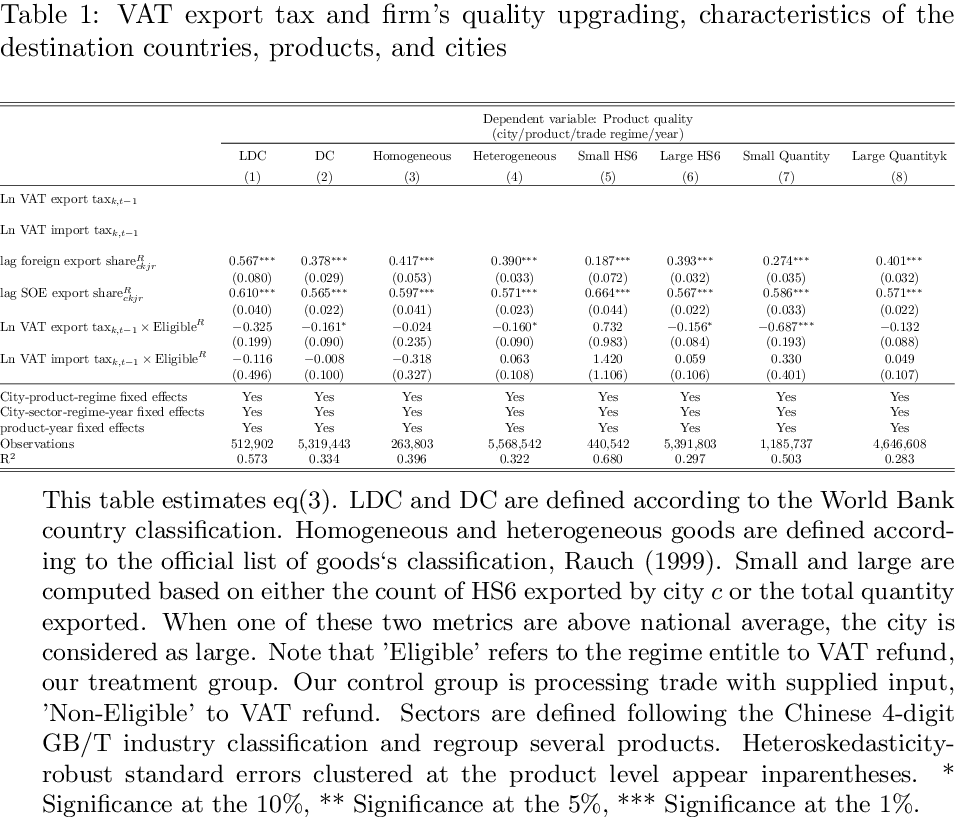

```python
tbe1  = """
This table estimates eq(3).
LDC and DC are defined according to the World Bank country classification.
Homogeneous and heterogeneous goods are defined according to the official list of goods`s classification, Rauch (1999).
Small and large are computed based on either the count of HS6 exported by city $c$ or the total quantity exported.
When one of these two metrics are above national average, the city is considered as large.
Note that 'Eligible' refers to the regime entitle to VAT refund, our treatment group.
Our control group is processing trade with supplied input, 'Non-Eligible' to VAT refund.
Sectors are defined following the Chinese 4-digit GB/T industry
classification and regroup several products.
Heteroskedasticity-robust standard errors
clustered at the product level appear inparentheses.
\sym{*} Significance at the 10\%, \sym{**} Significance at the 5\%, \sym{***} Significance at the 1\%."""

multicolumn ={
    'LDC': 1,
    'DC': 1,
    'Homogeneous': 1,
    'Heterogeneous': 1,
    'Small HS6': 1,
    'Large HS6': 1,
    'Small Quantity': 1,
    'Large Quantityk': 1,
}
multi_lines_dep = '(city/product/trade regime/year)'
#new_r = ['& Eligible', 'Non-Eligible', 'All', 'All benchmark']
lb.beautify(table_number = 1,
            #multi_lines_dep = None,
            multi_lines_dep = multi_lines_dep,
            new_row= False,
            multicolumn = multicolumn,
            table_nte = tbe1,
            jupyter_preview = True,
            resolution = 200)
```

## Table 3: Countries, goods and cities characteristics, with covariates city, regime, product

$$ \begin{aligned} \operatorname{Quality}_{c,k,j, t}^{R} &=\alpha \ln \operatorname{VAT} \operatorname{Export} \operatorname{tax}_{k, t-1} \times \text { Eligibility }^{R} \\ &+F E_{c,k}^{R}+F E_{c,s,t}^{R}+ F E_{k, t}+\epsilon_{ck,j, t}^{R} \end{aligned} $$

- Column 1: Estimate baseline regression subset LDC countries: `income_group_ldc_dc` -> `LDC`
  - FE:
    - city-product-regime: `fe_ckr`
    - city-sector-regime-year: `fe_csrt`
    - product-year: `fe_kt`
- Column 2: Estimate baseline regression subset DC countries: `income_group_ldc_dc` -> `DC`
  - FE:
    - city-product-regime: `fe_ckr`
    - city-sector-regime-year: `fe_csrt`
    - product-year: `fe_kt`
- Column 3: Estimate baseline regression subset Homogeneous goods: `classification` -> `HOMOGENEOUS`
  - FE:
    - city-product-regime: `fe_ckr`
    - city-sector-regime-year: `fe_csrt`
    - product-year: `fe_kt`
- Column 4: Estimate baseline regression subset heterogeneous goods: `classification` -> != `HOMOGENEOUS`
  - FE:
    - city-product-regime: `fe_ckr`
    - city-sector-regime-year: `fe_csrt`
    - product-year: `fe_kt`
- Column 5: Estimate baseline regression subset small cities: `size_product` -> == `SMALL_COUNT`
  - FE:
    - city-product-regime: `fe_ckr`
    - city-sector-regime-year: `fe_csrt`
    - product-year: `fe_kt`
- Column 6: Estimate baseline regression subset large cities: `size_product` -> == `LARGE_COUNT`
  - FE:
    - city-product-regime: `fe_ckr`
    - city-sector-regime-year: `fe_csrt`
    - product-year: `fe_kt`
- Column 7: Estimate baseline regression subset small cities: `size_quantity` -> == `SMALL_QUANTITY`
  - FE:
    - city-product-regime: `fe_ckr`
    - city-sector-regime-year: `fe_csrt`
    - product-year: `fe_kt`
- Column 8: Estimate baseline regression subset large cities: `size_quantity` -> == `LARGE_QUANTITY`
  - FE:
    - city-product-regime: `fe_ckr`
    - city-sector-regime-year: `fe_csrt`
    - product-year: `fe_kt`

Sector is defined as the GBT 4 digits

```python
#### COUNTRIES
t_0 <- felm(kandhelwal_quality ~ln_lag_tax_rebate* regime + ln_lag_import_tax * regime+ ln_lag_import_tax +
            lag_foreign_export_share_ckr + lag_soe_export_share_ckr
            | fe_ckr + fe_csrt+fe_kt|0 | hs6, df_final %>% filter(income_group_ldc_dc == 'LDC'),
            exactDOF = TRUE)

t_1 <- felm(kandhelwal_quality ~ln_lag_tax_rebate* regime + ln_lag_import_tax * regime+ ln_lag_import_tax +
            lag_foreign_export_share_ckr + lag_soe_export_share_ckr
            | fe_ckr + fe_csrt+fe_kt|0 | hs6, df_final %>% filter(income_group_ldc_dc != 'LDC'),
            exactDOF = TRUE)

#### GOODS
t_2 <- felm(kandhelwal_quality ~ln_lag_tax_rebate* regime + ln_lag_import_tax * regime+ ln_lag_import_tax +
            lag_foreign_export_share_ckr + lag_soe_export_share_ckr
            | fe_ckr + fe_csrt+fe_kt|0 | hs6, df_final %>% filter(is.na(homogeneous) | homogeneous == 'HOMOGENEOUS'),
            exactDOF = TRUE)

t_3 <- felm(kandhelwal_quality ~ln_lag_tax_rebate* regime + ln_lag_import_tax * regime+ ln_lag_import_tax +
            lag_foreign_export_share_ckr + lag_soe_export_share_ckr
            | fe_ckr + fe_csrt+fe_kt|0 | hs6, df_final %>% filter(homogeneous == 'HETEREGENEOUS'),
            exactDOF = TRUE)

#### CITIES
##### HS6
t_4 <- felm(kandhelwal_quality ~ln_lag_tax_rebate* regime + ln_lag_import_tax * regime+ ln_lag_import_tax +
            lag_foreign_export_share_ckr + lag_soe_export_share_ckr
            | fe_ckr + fe_csrt+fe_kt|0 | hs6, df_final %>% filter(size_product == 'SMALL_COUNT'),
            exactDOF = TRUE)

t_5 <- felm(kandhelwal_quality ~ln_lag_tax_rebate* regime + ln_lag_import_tax * regime+ ln_lag_import_tax +
            lag_foreign_export_share_ckr + lag_soe_export_share_ckr
            | fe_ckr + fe_csrt+fe_kt|0 | hs6, df_final %>% filter(size_product == 'LARGE_COUNT'),
            exactDOF = TRUE)
##### Quantity
t_6 <- felm(kandhelwal_quality ~ln_lag_tax_rebate* regime + ln_lag_import_tax * regime+ ln_lag_import_tax +
            lag_foreign_export_share_ckr + lag_soe_export_share_ckr
            | fe_ckr + fe_csrt+fe_kt|0 | hs6, df_final %>% filter(size_quantity == 'SMALL_QUANTITY'),
            exactDOF = TRUE)

t_7 <- felm(kandhelwal_quality ~ln_lag_tax_rebate* regime + ln_lag_import_tax * regime+ ln_lag_import_tax +
            lag_foreign_export_share_ckr + lag_soe_export_share_ckr
            | fe_ckr + fe_csrt+fe_kt|0 | hs6, df_final %>% filter(size_quantity == 'LARGE_QUANTITY'),
            exactDOF = TRUE)
```

```python
import os
try:
    os.remove("Tables/table_2.txt")
except:
    pass
try:
    os.remove("Tables/table_2.tex")
except:
    pass
try:
    os.remove("Tables/table_2.pdf")
except:
    pass
```

```python
dep <- "Dependent variable: Product quality"
fe1 <- list(
    c("City-product-regime fixed effects","Yes", "Yes", "Yes", "Yes","Yes", "Yes","Yes", "Yes"),

    c("City-sector-regime-year fixed effects","Yes", "Yes", "Yes", "Yes","Yes", "Yes","Yes", "Yes"),

    c("product-year fixed effects", "Yes", "Yes", "Yes", "Yes","Yes", "Yes","Yes", "Yes")
             )

table_1 <- go_latex(list(
    t_0,t_1, t_2, t_3, t_4,t_5, t_6, t_7
),
    title="VAT export tax and firm’s quality upgrading, characteristics of the destination countries, products, and cities",
    dep_var = dep,
    addFE=fe1,
    save=TRUE,
    note = FALSE,
    name="Tables/table_2.txt"
)
```

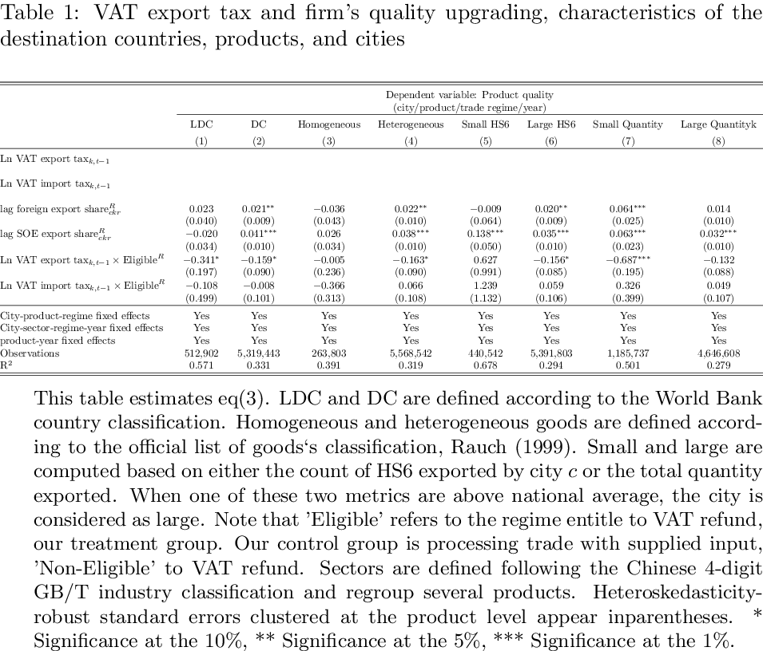

```python
tbe1  = """
This table estimates eq(3).
LDC and DC are defined according to the World Bank country classification.
Homogeneous and heterogeneous goods are defined according to the official list of goods`s classification, Rauch (1999).
Small and large are computed based on either the count of HS6 exported by city $c$ or the total quantity exported.
When one of these two metrics are above national average, the city is considered as large.
Note that 'Eligible' refers to the regime entitle to VAT refund, our treatment group.
Our control group is processing trade with supplied input, 'Non-Eligible' to VAT refund.
Sectors are defined following the Chinese 4-digit GB/T industry
classification and regroup several products.
Heteroskedasticity-robust standard errors
clustered at the product level appear inparentheses.
\sym{*} Significance at the 10\%, \sym{**} Significance at the 5\%, \sym{***} Significance at the 1\%."""

multicolumn ={
    'LDC': 1,
    'DC': 1,
    'Homogeneous': 1,
    'Heterogeneous': 1,
    'Small HS6': 1,
    'Large HS6': 1,
    'Small Quantity': 1,
    'Large Quantityk': 1,
}
multi_lines_dep = '(city/product/trade regime/year)'
#new_r = ['& Eligible', 'Non-Eligible', 'All', 'All benchmark']
lb.beautify(table_number = 2,
            #multi_lines_dep = None,
            multi_lines_dep = multi_lines_dep,
            new_row= False,
            multicolumn = multicolumn,
            table_nte = tbe1,
            jupyter_preview = True,
            resolution = 200)
```

# Generate reports

```python
import os, time, shutil, urllib, ipykernel, json
from pathlib import Path
from notebook import notebookapp
```

```python
def create_report(extension = "html", keep_code = False):
    """
    Create a report from the current notebook and save it in the
    Report folder (Parent-> child directory)

    1. Exctract the current notbook name
    2. Convert the Notebook
    3. Move the newly created report

    Args:
    extension: string. Can be "html", "pdf", "md"


    """

    ### Get notebook name
    connection_file = os.path.basename(ipykernel.get_connection_file())
    kernel_id = connection_file.split('-', 1)[0].split('.')[0]

    for srv in notebookapp.list_running_servers():
        try:
            if srv['token']=='' and not srv['password']:
                req = urllib.request.urlopen(srv['url']+'api/sessions')
            else:
                req = urllib.request.urlopen(srv['url']+ \
                                             'api/sessions?token=' + \
                                             srv['token'])
            sessions = json.load(req)
            notebookname = sessions[0]['name']
        except:
            pass

    sep = '.'
    path = os.getcwd()
    #parent_path = str(Path(path).parent)

    ### Path report
    #path_report = "{}/Reports".format(parent_path)
    #path_report = "{}/Reports".format(path)

    ### Path destination
    name_no_extension = notebookname.split(sep, 1)[0]
    source_to_move = name_no_extension +'.{}'.format(extension)
    dest = os.path.join(path,'Reports', source_to_move)

    ### Generate notebook
    if keep_code:
        os.system('jupyter nbconvert --to {} {}'.format(
    extension,notebookname))
    else:
        os.system('jupyter nbconvert --no-input --to {} {}'.format(
    extension,notebookname))

    ### Move notebook to report folder
    #time.sleep(5)
    shutil.move(source_to_move, dest)
    print("Report Available at this adress:\n {}".format(dest))
```

```python
create_report(extension = "html")
```